# 432: Lab 03

# 2 Question 2

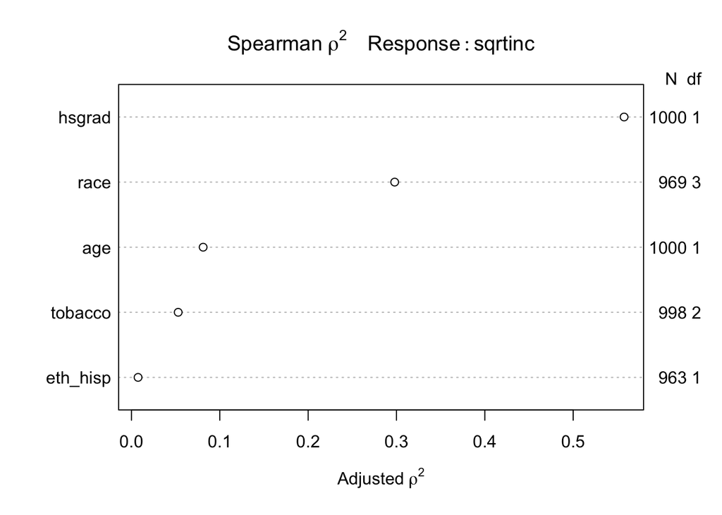

```r
# create spearman plot to see which variables may be good to make non-linear
spearman_obj <- spearman2(sqrtinc ~ hsgrad + race + eth_hisp + age + tobacco,
                           data = hbp_b)

plot(spearman_obj)
```

From this Spearman $\rho^2$ plot, we can see that if we want to use a non-linear term, `hsgrad` would clearly be the best choice. This is because higher scores indicate a variable performing better as a non-linear term and `hsgrad` has the highest Adjusted $\rho^2$ value by a wide margin.

# 3 Question 3

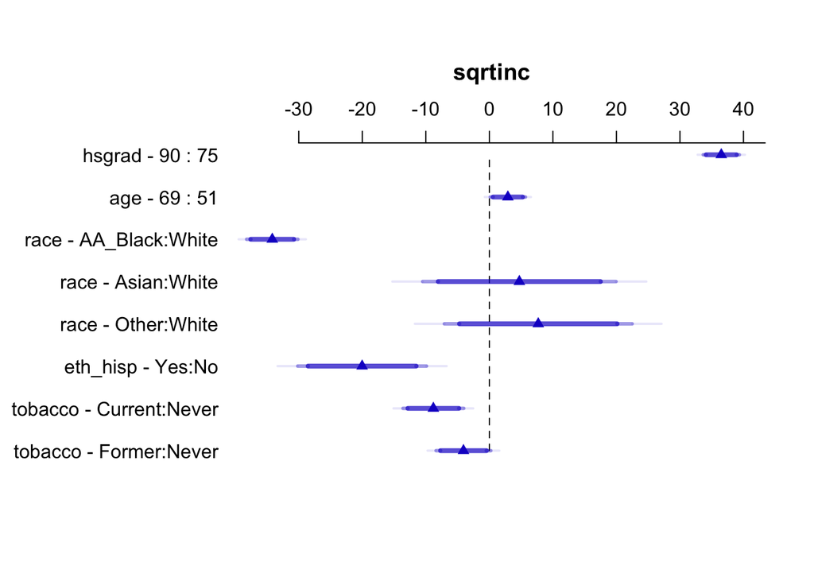

```r
# create OLS model
dd <- datadist(hbp_b)
options(datadist = "dd")

m1 <- ols(sqrtinc ~ hsgrad + race + eth_hisp + age + tobacco,
                           data = hbp_b, x = TRUE, y = TRUE)

# plot the model
plot(summary(m1))
```

```r
# get coefficients of linear model
m1_lm <- lm(sqrtinc ~ hsgrad + race + eth_hisp + age + tobacco,
                           data = hbp_b)

m1_lm
```

```
Call:
lm(formula = sqrtinc ~ hsgrad + race + eth_hisp + age + tobacco,
    data = hbp_b)

Coefficients:
  (Intercept)         hsgrad      raceAsian      raceOther      raceWhite
     -43.2880         2.4341        38.8923        41.8689        34.1708
  eth_hispYes            age  tobaccoFormer   tobaccoNever
     -20.0290         0.1619         4.7386         8.8151
```

```r
# ensure model has 8 degrees of freedom
anova(m1)
```

```
                Analysis of Variance          Response: sqrtinc

 Factor     d.f. Partial SS MS          F      P
 hsgrad       1   518557.08 518557.0751 640.19 <.0001
 race         3   230265.61  76755.2025  94.76 <.0001
 eth_hisp     1    12184.08  12184.0839  15.04 0.0001
 age          1     3468.92   3468.9196   4.28 0.0388
 tobacco      2    10937.67   5468.8366   6.75 0.0012
 REGRESSION   8  1272864.01 159108.0016 196.43 <.0001
 ERROR      947   767080.00    810.0106
```

The `hsgrad` coefficient shown in the effect summary plot indicates how much the predicted `sqrtinc` value will be affected by a change in `hsgrad` value from 75 to 90. The values 75 and 90 are specified because they are the 25th and 75th percentile values of `hsgrads`. With this point estimate, we can determine that the change in `sqrtinc` value for if `hsgrad` changes from 75 to 90 is ~37 if all else is held constant. This can be verified by calculating the actual difference using the `hsgrad` coefficient of 2.4341, where we can see that (2.4341 * 90) - (2.4341 * 75) = 36.5115.